# What questions can this dataset answer?

# Research Questions You Can Answer

This dataset has **three dimensions** you can play with — pick two and compare:

```
                Study arm
           (yogurt vs diet)
                 │
     Time ───────┼─────── Cytokines / qPCR
  (baseline vs         (10 immune markers,
   after abx)          3 bacterial measures)
                 │
        Participant traits
      (age, birth control, etc.)
```

## Question Type 1: “Does yogurt change things?” ← the main study question

Compare yogurt vs unchanged diet on any outcome.

**Examples:** - Does yogurt change total bacterial levels? - Do yogurt eaters have more *L. crispatus* (the “good” bacteria)? - Are cytokine levels different between groups? - Does birth control type differ between arms? (potential confounder)

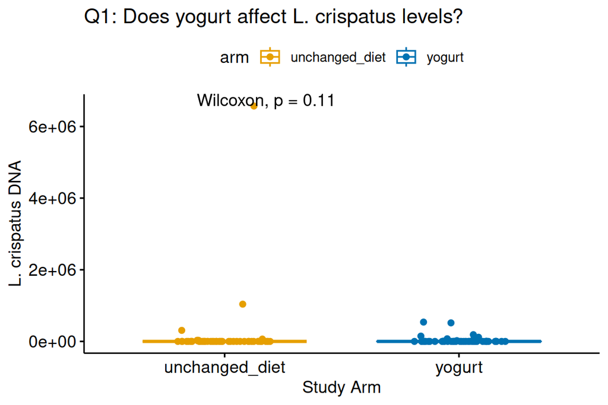

```r
qpcr |>
  left_join(select(sample_ids, sample_id, arm), by = "sample_id") |>
  ggboxplot(x = "arm", y = "qpcr_crispatus", color = "arm",
            palette = c("#E69F00", "#0072B2"), add = "jitter") +
  stat_compare_means(method = "wilcox.test") +
  labs(title = "Q1: Does yogurt affect L. crispatus levels?",
       x = "Study Arm", y = "L. crispatus DNA")
```

**Analysis tool:** `tbl_summary(by = arm)` + `add_p()` for the Table 1, then `ggboxplot()` + `stat_compare_means()` for each outcome.

## Question Type 2: “Does time matter?” (before vs after antibiotics)

Every participant was sampled at **baseline** and again **after antibiotics**. You can ask if things change over time, regardless of yogurt.

**Examples:** - Do total bacteria go down after antibiotics? - Does *L. crispatus* drop after antibiotics? Does it recover more in yogurt eaters? - Do inflammatory cytokines change from baseline to after antibiotics?

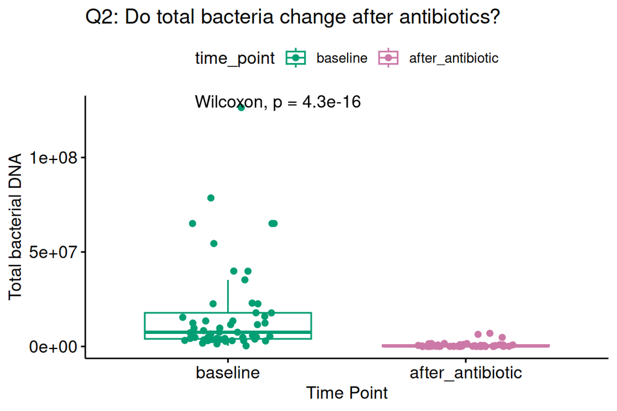

```r
qpcr |>
  left_join(select(sample_ids, sample_id, time_point), by = "sample_id") |>
  ggboxplot(x = "time_point", y = "qpcr_bacteria", color = "time_point",
            palette = c("#009E73", "#CC79A7"), add = "jitter") +
  stat_compare_means(method = "wilcox.test") +
  labs(title = "Q2: Do total bacteria change after antibiotics?",
       x = "Time Point", y = "Total bacterial DNA")
```

**Analysis tool:** `ggboxplot(x = "time_point", y = "outcome")` + `stat_compare_means(method = "wilcox.test", paired = TRUE)` — they’re paired samples (same person, two time points), so `paired = TRUE` gives more power.

## Question Type 3: “Does yogurt help *after antibiotics*?” (interaction)

The most interesting question: **does the yogurt effect differ by time point?** Maybe yogurt doesn’t matter at baseline, but it helps *L. crispatus* recover after antibiotics. This is the **interaction** question.

**Examples:** - Is the yogurt effect on *L. crispatus* stronger after antibiotics? - Do cytokines in yogurt eaters return to baseline faster? - Is there a time × arm interaction for total bacteria?

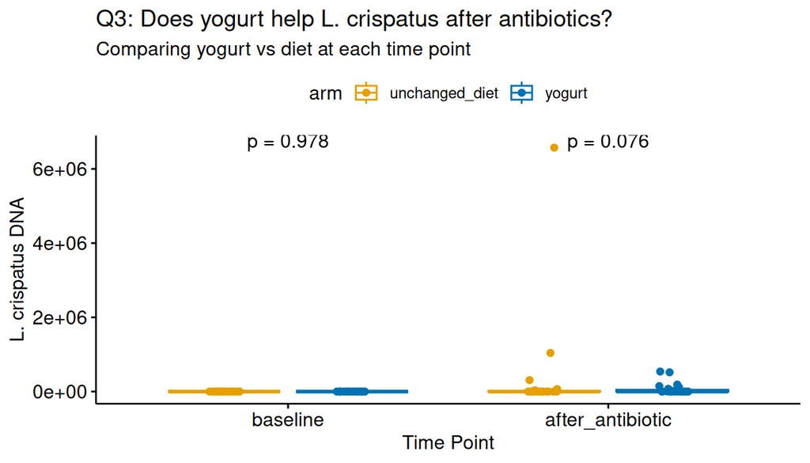

```r
qpcr |>
  left_join(select(sample_ids, sample_id, arm, time_point), by = "sample_id") |>
  ggboxplot(x = "time_point", y = "qpcr_crispatus", color = "arm",
            palette = c("#E69F00", "#0072B2"), add = "jitter") +
  stat_compare_means(aes(group = arm), method = "wilcox.test",
                     label = "p.format") +
  labs(title = "Q3: Does yogurt help L. crispatus after antibiotics?",
       subtitle = "Comparing yogurt vs diet at each time point",
       x = "Time Point", y = "L. crispatus DNA")
```

**Analysis tool:** Two approaches — (a) split by time point and compare arms separately with `stat_compare_means()`, or (b) run a two-way model: `lm(qpcr_crispatus ~ arm * time_point)` and look at the interaction term.

## Question Type 4: “Do participant traits matter?” (by age, birth control, etc.)

Use the metadata to stratify or adjust.

**Examples:** - Does birth control type affect *L. crispatus* levels? - Are older participants different from younger ones? - Is days_since_last_sex associated with any cytokine? - After controlling for birth control, does yogurt still show an effect?

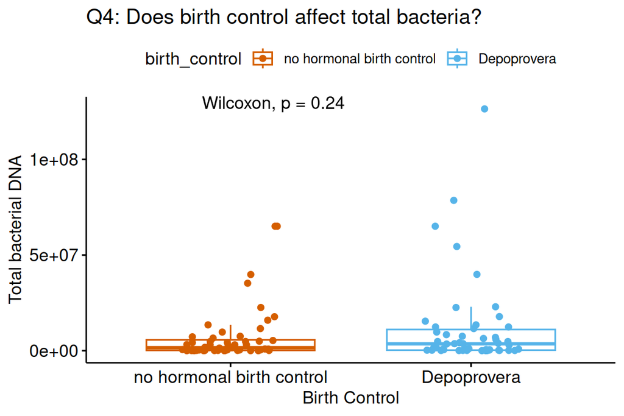

```r
qpcr |>
  left_join(select(sample_ids, sample_id, pid), by = "sample_id") |>
  left_join(select(metadata, pid, birth_control), by = "pid") |>
  ggboxplot(x = "birth_control", y = "qpcr_bacteria", color = "birth_control",
            palette = c("#D55E00", "#56B4E9"), add = "jitter") +
  stat_compare_means(method = "wilcox.test") +
  labs(title = "Q4: Does birth control affect total bacteria?",
       x = "Birth Control", y = "Total bacterial DNA")
```

**Analysis tool:** Same `ggboxplot()` pattern but swap the x-axis for a participant trait. Or use `tbl_summary(by = birth_control)` to describe.

## Question Type 5: “Are bacteria and immune markers connected?” (correlation)

This is a **correlation** question — do *L. crispatus* levels go with higher or lower cytokine concentrations?

**Examples:** - Do people with more *L. crispatus* have lower IL-8 (inflammation)? - Is *L. iners* associated with higher cytokine levels? - Which cytokines correlate most strongly with bacterial levels?

[figure not shown]

```r
# Pick one cytokine to show
qpcr |>
  left_join(select(sample_ids, sample_id, pid), by = "sample_id") |>
  left_join(
    luminex |> filter(cytokine == "IL-8") |> select(sample_id, conc),
    by = "sample_id"
  ) |>
  ggplot(aes(x = qpcr_crispatus, y = conc)) +
  geom_point(aes(color = qpcr_crispatus > 0), alpha = 0.6, size = 2.5) +
  geom_smooth(method = "lm", se = FALSE, color = "grey40", linetype = "dashed") +
  stat_cor(method = "spearman", label.x.npc = "right", label.y.npc = "top") +
  scale_color_manual(values = c("FALSE" = "grey70", "TRUE" = "#0072B2")) +
  labs(title = "Q5: Is L. crispatus linked to IL-8?",
       x = "L. crispatus DNA", y = "IL-8 concentration",
       color = "Detected?") +
  theme(legend.position = "bottom")
```

**Analysis tool:** `ggplot(aes(x = bacteria, y = cytokine))` + `geom_point()` + `geom_smooth(method = "lm")` + `stat_cor()`. Spearman correlation handles the zeros and skew better than Pearson here.

## Quick reference: which method for which question

| You want to… | Use this | Code pattern |
| --- | --- | --- |
| Compare 2 groups on 1 outcome | Wilcoxon or t-test | `ggboxplot(x = "arm", y = "outcome") + stat_compare_means()` |
| Compare before vs after (paired) | Paired Wilcoxon | `stat_compare_means(paired = TRUE)` |
| Compare across time × group | Two-way interaction | `lm(y ~ arm * time_point)` or facet |
| Screen many outcomes at once | Faceted boxplots | `facet_wrap(~ outcome, scales = "free_y")` |
| Describe participant traits | Table 1 | `tbl_summary(by = arm)` |
| Find correlations between measures | Scatter + correlation test | `ggplot + geom_point + stat_cor(method = "spearman")` |
| Check if a confounder matters | Stratify or add covariate | Split by birth control, or use `lm(y ~ arm + bc)` |

```
**Bottom line:** this dataset can answer about 15-20 meaningful questions
 across these 5 categories. Pick the one that interests you most and run with it.
```